[output not shown]

```r
# Seed for random number generation
set.seed(42)
knitr::opts_chunk$set(cache.extra = knitr::rand_seed)
```

The languages we speak today are not the same as the ones we spoke 300 years ago. Nor are they the same as the ones we spoke 500, 1000, or 2000 years ago. Why do languages change, aside from acquiring new vocabulary? One working theory is that they evolve to adapt to two dynamic competing pressures: (1) to be easily learned and transmitted, and (2) to be effective for communication [@kirby2015].

While children are often the actors who drive language evolution [@senghas2003], they differ from adults in their cognitive capabilities [@kempe2015], interests and early vocabularies, and conversation partners. As early language producers who are inundated with new information each day, children may be particularly biased towards simplification [@senghas2003]. Indeed, when children are learning language, they often make simplification errors [@bowerman1984]. This reflects the influence of the transmissibility pressure – children may latch onto word–forms which are simpler and thus easier to acquire. For example, if a child is asking for her bottle, she may be unable to produce the canonical label “bottle”, and may produce the simplified form, “baba”, instead. If this child grew up without competent speakers of the language and, unlike an average child, failed to have multiple opportunities to acquire the correct label, it is possible that she would retain and reproduce “baba”, even to her children in the future. In this way, her error is retained in the language and sustained over generations. With too many of these simplification errors, however, a language can lose its ability to be effective for communication [@kempe2014]. What enables languages to retain their communicative utility and expressivity in the face of these learnability pressures?

Children do not learn language in isolation, but they communicate with fluent speakers of the language—their parents and caregivers. Caregivers are able to combine their children’s productions with both their own knowledge of the language as well as their knowledge of their children. This enables caregivers to be excellent interpreters of child utterances [@chouinard2003]. Their interpretation skills may be a form of scaffolding for their children’s language learning [@lustigman2019]. Parents are able to successfully interpret a more simplified utterance, thus shouldering some of the complexity of the language – for a short time. Our hypothetical child may continue to call a bottle “baba” until she can handle the cognitive load of “bottle”, and her caregivers will support this learning in multiple ways.

Caregivers, through their explicit interventions as well as their implicit modeling of correct language, may be scaffolding their children’s language–learning, by providing a space for their children to simplify, as well as by re–introducing complexity into their communications. Adults can explicitly correct their children’s language errors in various ways [e.g., by interruptions or repeating the correct word/grammatical form; @penner1987]. Yet, children primarily learn language through listening to others talk, rather than explicit instruction [@romberg2010]. Thus, parents’ modeling of accurate language constructions can have a powerful effect on reducing children’s language errors: over time, children fix their own mistakes because they have had multiple opportunities to learn correct constructions from their caregivers [@hudsonkam2005]. By way of this feedback, both implicit and explicit, children’s simplification errors are corrected, and children are able to acquire adult–like speech. Eventually, when a child becomes an adult, they will not transmit the errors they previously had, but the correct forms they learned from their caregivers – as long as learning the correct forms is useful and necessary. Thus, over the course of a lifetime, the child language learner grows to become a parent language teacher, correcting their own children’s errors. These error reconstructions may be a mechanism by which more complexity is retained in language over many lifetimes than children could sustain alone.

## Using iterated reproduction to study language change

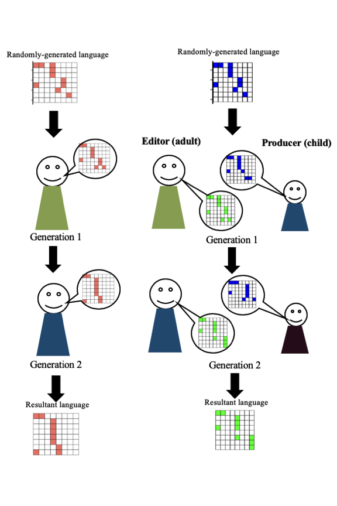

Experiments 1a, 2a, and 3a follow the conventional diffusion chain (iterated learning) paradigm, where a novel language is transmitted vertically through successive learning and recall. In Experiments 1b, 2b, and 3b, an element of horizontal transmission is added to the paradigm: novel language producers’ reproductions are subject to alterations from a secondary participant, whose input is passed to the subsequent generation.

```r
img <- png::readPNG("figs/FINAL_Schema.png")
grid::grid.raster(img)
```

To model the impact of these competing pressures on language evolution in the laboratory, we use a diffusion chain paradigm developed by [@kirby2008]. In this paradigm, one participant is trained on a randomly–generated language – e.g, a set of words created by arbitrarily pairing syllables together. The participant is later asked to recall the language, but inevitably makes some errors. Their errorful output becomes the training input for the subsequent participant, forming a transmission chain. This iterated learning process models the transmission of language over generations, with each participant unintentionally changing the language through their memory biases. The errors produced by participants reflect their memory or inductive biases—essentially, when the participant makes a mistake or mis–remembers, they rely on what they expect to see [@kalish2007].

We adapted @kempe2015’s non–linguistic iterated reproduction paradigm, as it has been used successfully with children [a similar task was used in non--human primates by @calidiere2014]. This paradigm uses a stimulus set of novel grid patterns, which are akin to language in that they are patterned, structured systems—just as early language learning is attuning to and recognizing patterns in sound @yurovsky2012. We therefore use this paradigm, adapted to an iPad and Amazon Mechanical Turk format, to model the effect of introducing a secondary, error–correcting participant on the evolution of language. We hypothesize that these error–correctors (analogous to caregivers and teachers) are important not only to an individual’s successful language acquisition, but also to the evolution of the language as a whole. This is because those who correct mistakes and provide feedback are able to protect against the strong transmissibility bias in early language producers by re–introducing and preserving complexity.

# Experiment 1a: Replicating Kempe et al. (2015)

We began by replication @kempe2015’s experiment using a nonlinguistic stimulus to study the evolution of structure in an artificial symbolic system. Our motivations for using this paradigm were twofold. First, the stimuli lent themselves to algorithmic quantification of complexity. Second, @kempe2015 used this paradigm successfully with children, and our goal was to test our hypotheses not just in adult–adult chains, but also in child–child and child–adult chains (Experiments 3a and 3b). We chose to use the diffusion chain paradigm for six transmission generations. Although @kempe2015 original study used ten transmission generations, the results appeared to approach stable levels of complexity at six generations, so this number was chosen as our starting point.

### Participants

Participants were 125 adults recruited on Amazon Mechanical Turk. Because five users failed to meet inclusion criteria, a larger number of participants was required to obtain the planned sample of 120. These participants were members of one of twenty diffusion chains, each of which had six generations. Each participant gave informed consent. The task was approximately eight minutes long, and subjects were compensated $0.50 for their participation.

### Design and Procedure

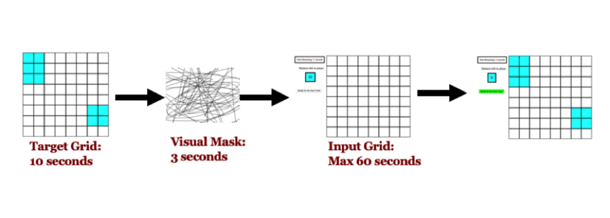

```r
img <- png::readPNG("figs/methods.png")
grid::grid.raster(img)
```

After completing one training and three practice trials, each participant completed 6 experiment trials. During the experimental trials, there was an additional display on the screen which informed the participant of how many trials they had left. Throughout the experimental trials, participants heard various engaging audio cues, including “You’re doing great, keep it up!”, “You’re halfway there!”, and “Just one more to go!”. These were added to the task to add an additional level of engagement for data collection with children (Experiments 3a and 3b). Participants in the first generation of each chain received the same initial grid patterns. These initial 8x8 grids were generated by randomly selecting 10 of the 64 possible cells to be filled using a random–number generator. Participants in subsequent generations received as their targets the outputs produced by the previous participant in their chain.

Complexity served as a proxy for expressiveness. The ideal mechanism for measuring complexity is still contested, therefore, we followed @kempe2015 in using several metrics: algorithmic complexity, chunking, and edge length. Algorithmic complexity was calculated using the Block Decomposition Method, a measure of Kolmogorov–Chaitin Complexity applied to 2–dimensional patterns [@feldman2006; @zenil2014]. This measure computes the length of the shortest Turing machine program required to produce the observed pattern. The shorter the program, the simpler the pattern. Chunking is the number of groups of colored blocks which share an edge. The more groups of blocks, the easier the pattern is to transmit, and the lower its complexity. Edge length is the total perimeter of the colored blocks and is similar to chunking. Implementation of these metrics was adapted from code provided by @gauvrit2017. While algorithmic complexity was our primary dependent variable of interest, chunking and edge length served as additional measures to check the reliability of the Block Decomposition Method.

# Experiment 1b: Introducing an Editor

This project aims to model the effects of the simplicity pressure present in language learning—retaining too much complexity in language is infeasible and unproductive. Without any scaffolds, adults are unable to retain the original complexity of the symbol system, as shown in Experiment 1a—instead, the patterns simplify to a more easily–transmissible level of complexity. What happens if scaffolding supports are introduced into the transmission process, just as they are in real–life with knowledgeable speakers, caregivers, and teachers?

In order to add an element of feedback from a more experienced interlocutor to the iterated reproduction process, we adapted the task from Experiment 1a to include a secondary, “editing” participant. This participant was analogous to a caregiver who protects their child from acquiring and perpetuating errors in symbol systems (i.e., language).

### Participants

Participants in Experiment 1b were 289 adults recruited on Amazon Mechanical Turk. Approximately 17% (n=49) of participants in Experiment 1b were excluded from analysis due to failure to meet accuracy requirements on the practice trials (n=38) or failure to select the necessary number of targets on one or more experimental trials (n=11). More participants who were designated as “editors” failed to meet accuracy requirements (n=23) compared to those who were designated as “producers” (n=15). This resulted in a total of 240 participants included in the analysis. These participants occupied one of twenty diffusion chains and one of six generations. Each participant gave informed consent and was compensated with $0.50 for their participation in this 8–minute task.

### Analysis

As in Experiments 1a and 1b, our primary measures of analysis were accuracy and complexity. Transmission accuracy was calculated as the proportion of 10 targets placed correctly, while complexity was measured using the Block Decomposition Method of algorithmic complexity [@zenil2014], as well as measures of chunking and edge length, as in Experiment 1a [@gauvrit2017].

# Experiment 2: Replication Study

# Experiment 2a: Adult Baseline Replication

This experiment replicated the task from Experiment 1a with the addition of twice as many chains and generations.

### Participants

Participants were 519 adults recruited on Amazon Mechanical Turk. Approximately 8% (n=39) of participants in Experiment 2a were excluded due to failure to meet accuracy requirements on the practice trials or failure to select the complete number of cells on one or more experimental trials. This resulted in a total of 480 participants included in the analysis. These participants were members of one of forty diffusion chains, each of which had twelve generations. Each participant gave informed consent and was compensated with $0.50 for their participation in this 8–minute task.

### Design and Procedure

The task in Experiment 2a was identical to Experiment 1a. Participants were told to reproduce patterns on a grid, and their responses were passed to the next subject in the transmission chain. They completed one training, three practice, and six experimental trials.

# Experiment 2b: Adult–Adult Dyad Replication

This experiment replicated the task from Experiment 1b with the addition of twice as many chains and generations. As in Experiment 1b, a secondary participant was assigned to be an “editor”, completing a variation of the standard iterated reproduction task.

### Participants

Participants in Experiment 2b were 1031 adults recruited on Amazon Mechanical Turk. Approximately 8% (n=71) of participants in Experiment 2b were excluded from analysis due to failure to meet accuracy requirements on the practice trials or failure to select the necessary number of targets on one or more experimental trials. This resulted in a total of 960 participants included in the analysis. These participants occupied one of forty transmission chains and one of twelve generations. Each participant gave informed consent and was compensated with $0.50 for their participation in this 8–minute task.

### Design and Procedure

The procedure in this task replicated that of Experiment 1b. As before, one participant was designated as a “producer”, who completed the standard iterated reproduction task. This participant was told to re–create patterns on a blank grid to match a target they had seen displayed for ten seconds. After the completion of one training, three practice, and six experimental trials, the producer’s data was passed to a second, “editing” participant. This participant was told to “fix” the producer’s patterns to match the same target, which they had also seen displayed for ten seconds. The editor’s edits were passed as the target for the subsequent generation. Together, the producer and editor occupied one “generation”.

## Experiments 1–2 Discussion

The combined results of Experiments 1a and 2a replicate the adult results found in a similar task by @kempe2015. In a standard iterated reproduction experiment, the complexity of adults’ produced patterns decreased over transmission generations to reach an asymptote. This shows that generational transmission creates a bottleneck in the evolutionary process, where patterned systems quickly lose complexity, but appear to reach a level of simplicity which is easier to reproduce. These results are supported by transmission accuracy findings, which show that participants become better at reproducing the target patterns over generations. These effects are robust, as they were replicated in two experiments. The pressure of passing a patterned system to a new participant modeled the simplicity pressure on language learning. In Experiment 2a, we see that the system did not simplify to nothingness but reached a more stable level of simplicity over transmissions. Thus, this system was not losing all of its descriptiveness, instead reaching a balance point between transmissibility and expressivity.

In a few instances, we also see significant effects of trial number, where the more trials a participant completes, the more complex their patterns become. Perhaps this is a fatigue issue, where participants are placing blocks randomly when they forget their exact location. However, this is contrary to the practice effect, which predicts that participants are actually becoming better at the task and are simply retaining more complexity because they remember the patterns better over time [@donovan1999].

The results of Experiments 1b and 2b attempt to more closely model pattern–system transmissions (loosely analogous to language–learning) using an iterated reproduction paradigm. These experiments introduce a secondary participant into the iterated reproduction process—a caregiver–like participant who has more knowledge about the novel system. These editing participants had higher transmission accuracies, reflecting their greater “knowledge” about the task and ability to reproduce more–accurate patterns compared to producers, who had to re–create grid patterns from scratch. This relationship is meant to mirror parents who have a relatively easier time recalling, editing, and producing language compared to early child language learners. Indeed, in Experiments 1b and 2b, “editors” were not simply completely re–creating the patterns made by “producers”, but they were fixing their errors.

The algorithmic complexity results of Experiment 1b and 2b show that the loss in complexity from Experiments 1a and 1b is not permanent cultural regression (Henrich, 2004), as complexity can be reintroduced in the patterned system by way of a secondary participant. When the iterated reproduction process begins to resemble the true process of language–learning, where there is an imbalance in knowledge during horizontal transmission, a lesser amount of complexity was lost during transmission. In Experiment 2b, the editor’s corrected “language” was passed to the next producer in the chain, representing a child who, after many years of being corrected by their own parent, becomes a parent, and, in turn, passes their language to the next generation. Due to the higher transmission accuracies, or knowledge, of editors, they were able to compensate for some (though not all) of the producers’ losses in complexity. Do these results hold, however, when there is a true working memory imbalance between participants, when the task is completed by adults and *real* children?

# Experiment 3a: Child Baseline

While experiments 1 and 2 were meant to mimic child language–learners, it is likely that there are significant differences between a child–like adult (i.e., the producers in Experiments 1b and 2b) and true children. As the goal of this project is to understand the role that children and adults—mirroring caregivers and parents—play in language evolution, we make a comparison between adults and children on the same iterated reproduction task. Although past iterated learning studies are meant to mirror language–learners, few use children as participants [@kempe2015; @raviv2018].

This experiment is identical to Experiment 1a, in that it is meant to gauge a baseline for how children perform during an iterated transmission task. Children in this experiment complete the task on iPads, primarily at a science museum in Chicago. iPads have been shown to be effective media for conducting experiments, especially with children, as they are engaging and intuitive to use [@frank2016]. Conducting the experiment on iPads also allows us to retain a high degree of comparability between experiments 1a–b and 2a–b, as although adults participated remotely online, and children participated in–person with an experimenter nearby, both groups of participants are completing the same task using technology.

The results of this experiment will inform us of whether iterated learning studies can equate child learners with adult learners—do children respond the same way to stimuli as adults? Do their iterated reproductions show similar trends as adults?

### Data Collection (can definitely be cut a lot)

Data collection is in progress for this experiment and will likely be completed by the end of Summer 2019. Therefore, reported results are incomplete and not finalized. Data for experiments 3a and 3b were collected simultaneously from August 2018–June 2019. Participants completed the task at one of three locations: The Museum of Science and Industry (MSI), Chicago; the University of Chicago campus, and a private school in Chicago. The majority of data was collected at the MSI. Data collection at all three locations followed similar procedures. All experimenters were trained by the first author to follow a script, and all experimenters were IRB–approved and trained to collect data at all locations.

At the MSI, experimenters from the Communication and Learning Lab arranged a table next to a popular exhibit for children under ten years old. A sign advertised available studies for the target age range, 6–8 years old. Interested families approached the experimenters at the table, who informed them of the general study procedures (a short, 8–minute iPad task), and obtained written consent. Many families also completed an optional demographics sheet, which included questions about caregiver education levels and the languages the child hears at home. After written consent was provided by a parent or legal guardian, and verbal consent was obtained from the child, children went with one of the experimenters to a nearby bench. The experimenter introduced the child to the task, explaining that they would be playing a memory game. Children were given headphones in order to hear the various audio cues throughout the task. The experimenter aided the child in the first training trial, demonstrating how “stickers” (colored blocks) could be placed or removed by tapping on the screen. Additional guidance was given during the first three practice trials if necessary, for example, if the child did not understand that they needed to place exactly 10 stickers down on each trial, or if they did not understand the reproduction element of the task. After the training and practice trials were complete, the experimenter ceased verbal contact with the child, except if the child wanted to end the study. If the child asked the experimenter a question, or expressed frustration about the difficulty of the task, the experimenter replied, “Just do your best.” After completion of the study, children received their choice of one or two stickers as compensation.

For participants who completed the study at the University of Chicago, the procedure was similar. The only differences were that participants were recruited through the UChicago Center for Early Childhood Research database, and scheduled appointments to come into the laboratory. After providing written consent (from parents/legal guardians) and verbal consent (from the child), children were taken into a separate, quiet room. Experimenters were trained to follow the same procedure described above. Participants were compensated with $10 and children received a book or toy for their participation.

At the local private school, consent forms were distributed to a kindergarten class prior to data collection. Those children who returned signed consent forms participated in the study. At the beginning of the school day, experimenters brought small groups of children to a quiet room, where they completed the task following the same procedure above. Children were compensated with stickers.

### Participants

Participants consisted of 89 children ages 6–8 ($\mu$ = 6.92 years; 54% male). 83 children completed the task at the Museum of Science and Industry, Chicago, and 2 participants completed the task on the University of Chicago campus. A small number of participants’ data (n=4) were collected at a private school in Chicago. 29 children were removed from the data set due to failure to complete the task, failure to select ten blocks on all experimental trials, or failure to meet accuracy requirements on two out of three practice trials. These participants were removed from the transmission chains, and their re–creations were not passed to the subsequent participant. This results in a total sample size of 60 participants ($\mu$ = 6.95 years; 53% male) which makes up 50% of our goal of 120 participants. The included data is relatively evenly–distributed across generations.

### Design and Procedure

The task for this experiment was identical to experiments 1a and 2a. Participants viewed a target grid pattern for ten seconds, followed by a visual mask, followed by a blank grid. Children had to tap on the grid to place colored blocks, while a counter dynamically marked how many (out of ten) were left to be placed. A timer counted down from 60 seconds to let the participant know how much time they had left on a particular trial. Auditory cues were presented throughout the task, to encourage the child (“You’re doing great!”) and to let them know when they were running out of time. After completing one training and three practice trials, participants completed six experimental trials. Participants were in one of 20 chains, each of which contained 6 generations. Children were compensated with stickers for their participation in this 6–10–minute task.

# Experiment 3b: Adult–Child Dyad

This experiment investigates whether introducing a secondary participant alters the patterned system’s evolution. This experiment uses the same paradigm as Experiments 1b and 2b, with one participant designated as a “producer” and another as an “editor”. Notably, in this experiment, children are designated as “producers” and adults are designated as “editors”. Thus, this condition is the closest step towards to the goal of understanding the impact of caregiver–child language correction in the language–evolution process.

### Data Collection

Data collection with children was identical to Experiment 3a. Participants were recruited, and data were collected at one of three locations: The Museum of Science and Industry, the University of Chicago, or a local private school.

### Participants

Participants consisted of 103 children ages 6–8 ($\mu$ = 6.84 years; 45% male) and 123 adults. 76 participants completed the task at the Museum of Science and Industry, Chicago, and 18 children completed the task on the University of Chicago campus. A small number of participants’ data (n=9) were collected at a private school in Chicago. All adults completed the task online on Amazon Mechanical Turk. 6 children were removed from the dataset due to failure to select ten blocks on all experimental trials, or failure to meet accuracy requirements on two out of three practice trials. 27 adults were removed from the dataset due to failure to select ten blocks on all experimental trials or failure to meet accuracy requirements.

### Design and Procedure

Because children were designated as producers in this dyad task, the task procedure was identical to that of Experiment 3a. Adults, who were designated to be “editors”, completed the task online on Amazon Mechanical Turk. Therefore, their procedure was identical to that of the editors in Experiments 1b and 2b. As in Experiment 1b, we chose to complete the task with twenty diffusion chains, transmitted over six generations. This choice was made after observing the results of @kempe2015, and additionally due to time constraints on collecting data with children.

## Experiment 3 Discussion

The results of Experiments 3a and 3b continue to push the diffusion chain paradigm further towards modeling true processes of language–learning, this time modeling language–learning by children—those who are the best language–learners. Although data collection is only 50% complete, in Experiment 3a, as in Experiment 1a, we see a dramatic linear decrease in algorithmic complexity over generations, coupled with a linear increase in transmission accuracy. This reflects the effects of the learnability pressure, which, as hypothesized, is especially strong in children. It also replicates the findings of @kempe2015.

In Experiment 3b, we see similar trends as were expected. Editors (adults) and producers (children) had significantly different reproduction accuracies, with editors being better at re–creating the target, just as they were in Experiment 2b. However, unlike in Experiment 2b or 1b, the reproduction accuracies of producers increased over generations. Thus, children were becoming better at reproducing the grid patterns over time, perhaps pointing to features of the grids which were facilitating easier transmission. Baseline children (Experiment 3a) had significantly higher transmission accuracies than child producers (Exp. 3b). However, the trends shown are somewhat different from those seen in Exps. 1b and 2b, with the child producer and baseline conditions being more similar than the adult baseline and producer conditions. Adult editors had significantly higher levels of complexity compared to baseline children. Thus, the addition of an adult editor—analogous to a parent or caregiver—allowed a significantly higher level of complexity to be retained in the language.

# General Discussion

In Experiments 1a and 2a, patterns produced by adults over transmission generations in an iterated reproduction task simplified rapidly and dramatically, reflecting the strong transmissibility pressure in memory–based tasks related to early language learning. With children ages 6–8, we see a similarly rapid, dramatic, and linear decrease in complexity of patterned systems over generations. These findings replicated those of @kempe2015: when transmitting an artificial patterned system, complexity was lost.

Editors in Experiment 1b, 2b, and 3b represented caregivers – they were more accurate at reproducing the grid patterns and could therefore be seen as more fluent speakers of the “language”. The producers, on the other hand, had a more difficult task, which greater strained their working memories, similar to the strain on a child language producer who is exposed to many new words each day. Indeed, when there were real children introduced into the iterated reproduction process, we see that editors still preserve and re–introduce complexity into the patterned systems. In fact, adult editors are able to re–introduce complexity to the level that adults attained on their own. Therefore, it seems that adults are able to compensate for children’s losses in complexity. Notably, producers in the child–adult dyad condition showed increases in transmission accuracies, unlike the editors in the same condition. Although the grid patterns were continuing to simplify, the patterns appeared to be evolving to be easier to transmit for children, but not for adults.

Despite the use of a non–linguistic task, we were able to measure change in a culturally–transmitted, reproduced symbol system. When an element of horizontal transmission more closely resembling the relationship between caregivers and children is introduced into the typical diffusion chain paradigm, a greater level of complexity is retained in an evolving “language”, as adults are able to re–introduce and protect against oversimplification.

# General Discussion (second one; integrate and remove qual analysis stuff)

In a number of iterated reproduction studies with both children and adults, we show the impact of introducing an element of horizontal transmission into the iterated reproduction paradigm. Additionally, we show similar, yet slightly different findings for adults and children, pointing to the importance of involving those who are the most frequent—and best—language–learners in studies meant to model language evolution.

Additionally, the results of this project suggest that introducing an element of horizontal transmission, namely, error–correction by a more knowledgeable participant, changes the system–transmission process. Yet, error–correction, whether explicit or implicit, is a constant, common part of the language–learning process. Therefore, when we attempt to model language evolution in the laboratory, we should include the relationships and phenomena which are found commonly in transmission.

Although the system of grid patterns transmitted and reproduced in this study is quite different, and quite abstracted from the language–learning process, we were able to successfully collect data with young children. The task was engaging, and it allowed us to manipulate the task difficulty level for comparison between adults and children. Many attempts to study language evolution with children in the past have failed, as the tasks used are either too simple or are too difficult for kids [@raviv2018]. However, it is important and necessary, in order to study language evolution, to study those who are most often learning and changing language [@senghas2003].

This study is a first, reliable step towards future studies implementing both horizontal and vertical transmission between children and adults in the patterned–system reproduction process. Overall, the results suggest that when a caregiver prevents their child from growing up to believe that “baba” is the word for “bottle”, they are not only helping their individual child become a competent speaker of the language, but they are also helping the language system as a whole from oversimplifying.

We do not learn language as passive listeners, who absorb a proportion of the linguistic input they hear. Therefore, we cannot measure language learning only through measuring input, nor through measuring only linguistic output. Language is both learned and changed through conversation to evolve to the needs of its users. Therefore, in order to understand how language adapts to and evolves with communicative interactions, we should study language learning in process.

# Acknowledgements

This work was funded by a James McDonnell Foundation Scholar Award to DY as well as an Earl R. Franklin Fellowship Award and a PRISM Research Grant to MM.